# WeightLiftDetection

boole2

April 22, 2016

# Abstract

With the increasing use of dressable devices able to collect personal activity information, the development of algorithm and related consumer or mediacal application are growing very fast. In this document we afford the proble of detecting not only the type of activity but also to indentify if the activity is implemented right or wrong. The context is Gym Weight Lifting with free tool, a common gym activity.

The data came from accelerometers on the belt, forearm, arm, and dumbell of 6 participants. They were asked to perform barbell lifts correctly and incorrectly in 5 different ways. One (class A) correspond to a correct execution of the weight lift exercise, the others 4 are all wrong.

After assessing the Data Set and their measure and meaning, we have proceed with data cleaning, correlation measure and data preparation. After reduction of the observable set, we have created a test set splitting the trainig sample for validation of the model (directly form training sample). In the second stage, we have proceed with model selection starting from a basic Classification Tree with very poor result (accuracy almost 0.5), and then proof a Random Forest. The result of this model for in sample and out of sample (testig) are excellent, and I have decided to retain this model for the 20 Test cases. The very high computation time for row data set have pushed me to try a GBM over the windows sammarized data (present in the original data set). The GBM perform with accuracy about 77% for out of sample but with very fast compuation time.

I thankfull the Group Ware team for suppling the sample data used in the document. http://groupware.les.inf.puc-rio.br/har.

# Data Set

As reported in the linked article the Data cames from sensors attach to the body and to the weight. The data came from accelerometers on the belt, forearm, arm, and dumbell of 6 participants.

Six young health participants were asked to perform one set of 10 repetitions of the Unilateral Dumbbell Biceps Curl in five different fashions: exactly according to the specification (Class A), throwing the elbows to the front (Class B), lifting the dumbbell only halfway (Class C), lowering the dumbbell only halfway (Class D) and throwing the hips to the front (Class E). The sensors are sampled with 45 Hz frequency and they measure the Euler angles to Detect the Spatial orientation of each Sensored Point (on the body and the weight). The three Euler angles and the accollerometer and gyroscope measure are given as row data and as means base on sliding windows of variable 0.5 till 2.5 seconds. For the first stage and model selection we use only row data, removing window summary data. For the second stage we use only Window Samarized data for comparison of the result.

```r
##Load Data Set.
sensor_data <- read.table(file = "//home//boole2//coursera//machinelearning//exame//pml-training.csv",sep = ",",header = TRUE , na.strings =c("NA", "", "#DIV/0!") )
# row data only
sensor_data_row <- sensor_data[ sensor_data$new_window ==  "no",  ]
# we romove colum with NA
index.row <- apply(sensor_data_row, 2,  function(x){ sum(is.na(x) ) })
# we romove colum with NA  (here the colum are full NA or without NA  so we do not use a threshold )
sensor_data_row <- sensor_data_row[ , which(index.row == 0)]
#we have only 60 observable for row data.
dim(sensor_data_row)
```

```
## [1] 19216    60
```

Removing not useful data and index from data set (first seven columns)

```r
sensor_data_row <- sensor_data_row[, -c(1:7)]
```

Preparation of Training set and test set for basic Cross Validation

```r
set.seed(12345)
inTraining <- createDataPartition(y= sensor_data_row$classe, p= 0.6, list = FALSE)
trainig <- sensor_data_row[inTraining, ]
testing <- sensor_data_row[ -inTraining, ]
dim(trainig)
```

```
## [1] 11532    53
```

```r
dim(testing)
```

```
## [1] 7684   53
```

# Exploratory Analysis and Feature Selection

In this section we proceed with Feature Selection. First we remove variable almost zero with low variability that do not help to explane the result class. We then build a Cross Correlation Matrix to detect Covariate with high correlation elegible for be removed (one of them) with out risk Bias but reducing variace inflations of the model.

We first detect the gyro_forearm_z variable is almost zero for every measure and will be removed form the data set.

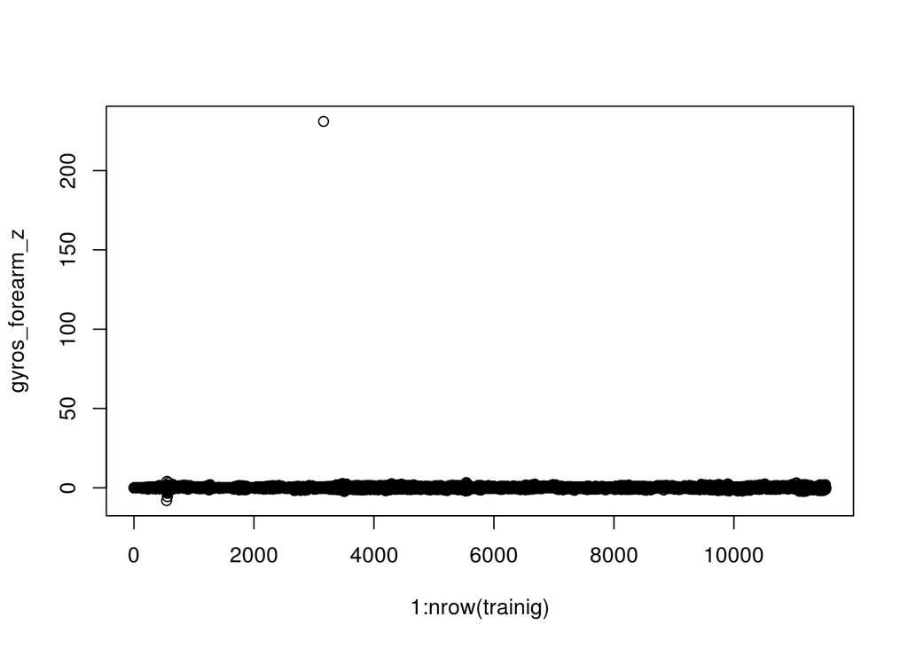

```r
M <- abs ( cor(trainig[, -53]) )
diag(M) <- 0
#  observable with high correlation
 which ( M  > 0.95, arr.ind = T)
```

```
##                  row col
## total_accel_belt   4   1
## accel_belt_z      10   1
## accel_belt_x       8   2
## roll_belt          1   4
## accel_belt_z      10   4
## pitch_belt         2   8
## roll_belt          1  10
## total_accel_belt   4  10
## gyros_dumbbell_z  33  31
## gyros_dumbbell_x  31  33
## gyros_forearm_z   46  33
## gyros_dumbbell_z  33  46
```

```r
#corrplot(M, order = "FPC", method = "circle",   type = "lower",
 #        tl.cex = 0.8, tl.col = rgb(0, 0, 0))

trainig <- trainig[,-46]
testing <- testing[,-46]
```

# Model Selection

Our first approch is to start simple, keeping inference capability at the first stage. So we try first with a Classification Tree model.

## Classification Tree

```
## CART
##
## 11532 samples
##    51 predictors
##     5 classes: 'A', 'B', 'C', 'D', 'E'
##
## No pre-processing
## Resampling: Bootstrapped (25 reps)
## Summary of sample sizes: 11532, 11532, 11532, 11532, 11532, 11532, ...
## Resampling results across tuning parameters:
##
##   cp          Accuracy   Kappa       Accuracy SD  Kappa SD
##   0.03370105  0.5126307  0.36563288  0.04890689   0.07994394
##   0.06206813  0.3996191  0.17922518  0.05647765   0.09482628
##   0.11662020  0.3376546  0.08047876  0.04168569   0.06165808
##
## Accuracy was used to select the optimal model using  the largest value.
## The final value used for the model was cp = 0.03370105.
```

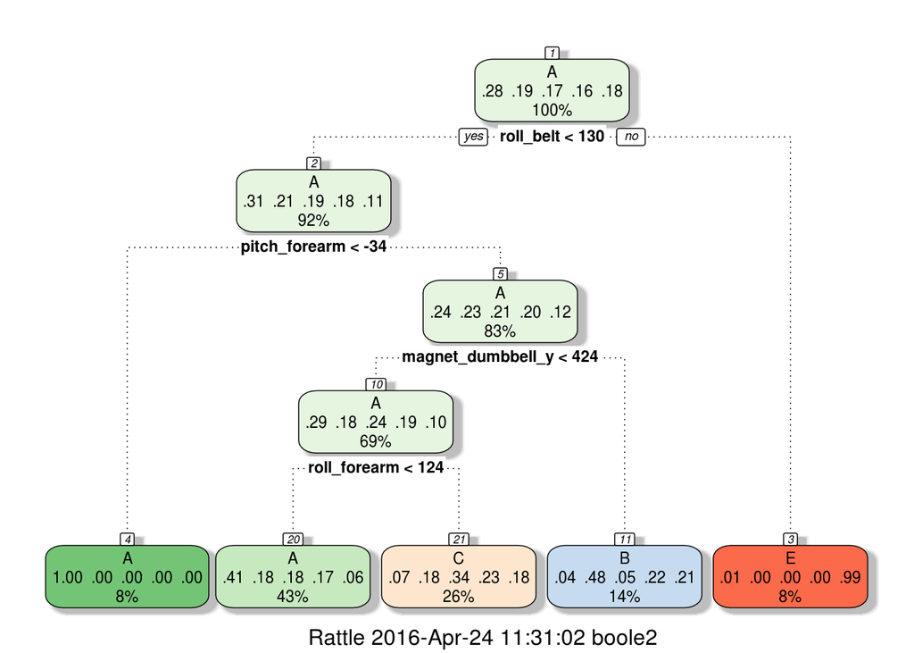

```
## rpart variable importance
##
##   only 20 most important variables shown (out of 51)
##
##                   Overall
## pitch_forearm      100.00
## roll_belt           89.22
## roll_forearm        74.89
## magnet_dumbbell_y   49.96
## accel_belt_z        44.05
## yaw_belt            42.27
## magnet_belt_y       42.21
## total_accel_belt    36.41
## magnet_arm_x        27.27
## accel_arm_x         27.08
## roll_dumbbell       18.83
## magnet_dumbbell_z   17.51
## roll_arm            16.31
## accel_dumbbell_y    13.82
## yaw_arm              0.00
## accel_dumbbell_x     0.00
## gyros_belt_y         0.00
## pitch_belt           0.00
## total_accel_arm      0.00
## magnet_dumbbell_x    0.00
```

Sensitivity of 0.5 is better then randomic class selection (0.20)

```r
tree.pedict <- predict(tree.fit, testing[-52] )
# very poor - Sensitivity of 0.5 is almost  equal to null model (randomic)
confusionMatrix(testing$classe,tree.pedict  )
```

```
## Confusion Matrix and Statistics
##
##           Reference
## Prediction    A    B    C    D    E
##          A 1947   59  174    0    8
##          B  596  528  363    0    0
##          C  604   58  678    0    0
##          D  548  245  465    0    0
##          E  198  189  402    0  622
##
## Overall Statistics
##
##                Accuracy : 0.4913
##                  95% CI : (0.48, 0.5025)
##     No Information Rate : 0.5066
##     P-Value [Acc > NIR] : 0.9966
##
##                   Kappa : 0.3361
##  Mcnemar's Test P-Value : NA
##
## Statistics by Class:
##
##                      Class: A Class: B Class: C Class: D Class: E
## Sensitivity            0.5001  0.48934  0.32565       NA  0.98730
## Specificity            0.9364  0.85481  0.88183   0.8363  0.88815
## Pos Pred Value         0.8899  0.35508  0.50597       NA  0.44082
## Neg Pred Value         0.6459  0.91109  0.77869       NA  0.99872
## Prevalence             0.5066  0.14042  0.27095   0.0000  0.08199
## Detection Rate         0.2534  0.06871  0.08824   0.0000  0.08095
## Detection Prevalence   0.2847  0.19352  0.17439   0.1637  0.18363
## Balanced Accuracy      0.7183  0.67207  0.60374       NA  0.93773
```

## Random Forest

To drammatically improve the model we try a Random Forest over Row Data.

```r
#avoid recompute every markdown run
if (FALSE){
        set.seed(434562)

        #we use default cross validation paramiter
        rf.fit  <- train( classe ~. ,  method = "rf", data = trainig)
         save(rf.fit, file = "rffit.RData")
}
         load(file = "rffit.RData", verbose = TRUE)
```

```
## Loading objects:
##   rf.fit
```

```r
print(rf.fit)
```

```
## Random Forest
##
## 11532 samples
##    51 predictors
##     5 classes: 'A', 'B', 'C', 'D', 'E'
##
## No pre-processing
## Resampling: Bootstrapped (25 reps)
## Summary of sample sizes: 11532, 11532, 11532, 11532, 11532, 11532, ...
## Resampling results across tuning parameters:
##
##   mtry  Accuracy   Kappa      Accuracy SD  Kappa SD
##    2    0.9840885  0.9798765  0.002339341  0.002949023
##   26    0.9848763  0.9808730  0.002320300  0.002933529
##   51    0.9760540  0.9697135  0.005461563  0.006922612
##
## Accuracy was used to select the optimal model using  the largest value.
## The final value used for the model was mtry = 26.
```

```r
varImp(rf.fit)
```

```
## rf variable importance
##
##   only 20 most important variables shown (out of 51)
##
##                      Overall
## roll_belt             100.00
## pitch_forearm          61.88
## yaw_belt               56.39
## magnet_dumbbell_z      45.29
## magnet_dumbbell_y      45.09
## pitch_belt             44.67
## roll_forearm           41.66
## accel_dumbbell_y       19.30
## roll_dumbbell          18.14
## accel_forearm_x        17.92
## magnet_dumbbell_x      17.50
## magnet_belt_z          16.41
## accel_belt_z           15.26
## accel_dumbbell_z       14.68
## magnet_belt_y          14.24
## total_accel_dumbbell   14.16
## magnet_forearm_z       13.11
## gyros_belt_z           11.74
## yaw_arm                11.45
## magnet_belt_x          10.67
```

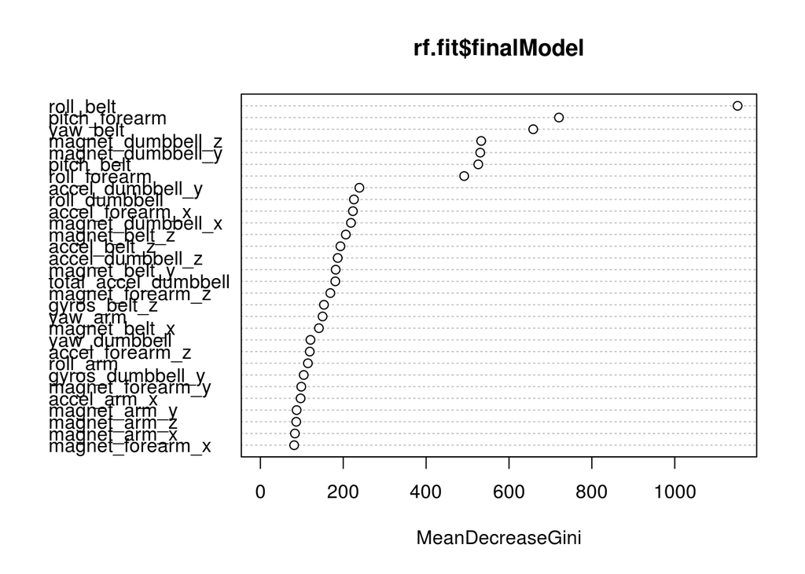

```r
varImpPlot(rf.fit$finalModel)
```

## Testing and Out of Sample test

We now test the Random Forest model with testing set. The accuracy for out of sample are very good. We kept this model for the 20 out of sample test (we the model get full score). Due to the high degree of accuracy of this model we do not implement an ensamble mobdel.

```r
rf.pedict <- predict(rf.fit, testing[-52] )
#
confusionMatrix(testing$classe,rf.pedict  )
```

```
## Confusion Matrix and Statistics
##
##           Reference
## Prediction    A    B    C    D    E
##          A 2183    2    2    1    0
##          B   18 1459    5    5    0
##          C    0    2 1330    8    0
##          D    0    0    7 1251    0
##          E    0    1    3    5 1402
##
## Overall Statistics
##
##                Accuracy : 0.9923
##                  95% CI : (0.9901, 0.9941)
##     No Information Rate : 0.2864
##     P-Value [Acc > NIR] : < 2.2e-16
##
##                   Kappa : 0.9903
##  Mcnemar's Test P-Value : NA
##
## Statistics by Class:
##
##                      Class: A Class: B Class: C Class: D Class: E
## Sensitivity            0.9918   0.9966   0.9874   0.9850   1.0000
## Specificity            0.9991   0.9955   0.9984   0.9989   0.9986
## Pos Pred Value         0.9977   0.9812   0.9925   0.9944   0.9936
## Neg Pred Value         0.9967   0.9992   0.9973   0.9970   1.0000
## Prevalence             0.2864   0.1905   0.1753   0.1653   0.1825
## Detection Rate         0.2841   0.1899   0.1731   0.1628   0.1825
## Detection Prevalence   0.2847   0.1935   0.1744   0.1637   0.1836
## Balanced Accuracy      0.9955   0.9960   0.9929   0.9920   0.9993
```

# Test with the 20 Test Case

```r
sensor_data.test <- read.table(file = "//home//boole2//coursera//machinelearning//exame//pml-testing.csv",sep = ",",header = TRUE , na.strings =c("NA", "", "#DIV/0!") )
index.row.test <- apply(sensor_data.test, 2,  function(x){ sum(is.na(x) ) })
# we romove colum with NA  (here the colum are full NA or without NA  so we do not use a threshold )
sensor_data_row.test <- sensor_data.test[ , which(index.row.test == 0)]
#we have only 60 observable for row data.
sensor_data_row.test <- sensor_data_row.test[, -c(1:7,53)]
```

Final resul that all match with quitz test.

```r
#sensor_data_row.test <- cbind( sensor_data_row.test, gyros_forearm_z = rep(0, 20))
rf.pedict.test <- predict(rf.fit, sensor_data_row.test )
rf.pedict.test
```

```
##  [1] B A B A A E D B A A B C B A E E A B B B
## Levels: A B C D E
```

# Comparison with Window Summary Data

The trade off of the firt Stage was the compuation time of Random Forest over Row data. So we try in this stage, to learn a Generalized Boosted Classifier over just the Windowed Sammarized data.

## Generalized Boosted Classifier

Preparation of Training set and test set. Basic we extract only the subset with New_windw = yes. they are 406 sample. Tne we proceed in the sameway as for row data.

```r
# we esxtract data set for  Windowed Summarized data.
sensor_data.w.summary <- sensor_data[ sensor_data$new_window ==  "yes",  ]
dim(sensor_data.w.summary)
```

```
## [1] 406 160
```

```r
index.window <- apply(sensor_data.w.summary, 2,  function(x){ sum(is.na(x) ) })

## we remove column with more  of NA
sensor_data.w.summary <- sensor_data.w.summary[ , which(index.window  == 0 )]
# we have 120 observales for the windows.
dim(sensor_data.w.summary)
```

```
## [1] 406 127
```

```r
sensor_data.w.summary <- sensor_data.w.summary[, -c(1:7)]

set.seed(12345)
inTraining <- createDataPartition(y= sensor_data.w.summary$classe, p= 0.6, list = FALSE)
trainig <- sensor_data.w.summary[inTraining, ]
testing <- sensor_data.w.summary[ -inTraining, ]
```

```r
# to avoid recomputation
if (FALSE){
        set.seed(434562)

         ct <- trainControl(method="repeatedcv", number=8, repeats = 8)

        gbm.fit  <- train( classe ~. ,  method = "gbm", data = trainig, trControl = ct, verbose = FALSE )
         save(gbm.fit, file = "gbmfit.RData")
}
      load(file = "gbmfit.RData", verbose = TRUE)
```

```
## Loading objects:
##   gbm.fit
```

```r
print(gbm.fit)
```

```
## Stochastic Gradient Boosting
##
## 246 samples
## 119 predictors
##   5 classes: 'A', 'B', 'C', 'D', 'E'
##
## No pre-processing
## Resampling: Cross-Validated (8 fold, repeated 8 times)
## Summary of sample sizes: 215, 216, 214, 215, 216, 216, ...
## Resampling results across tuning parameters:
##
##   interaction.depth  n.trees  Accuracy   Kappa      Accuracy SD
##   1                   50      0.7180076  0.6434790  0.08867649
##   1                  100      0.7270697  0.6551732  0.08397212
##   1                  150      0.7342007  0.6639358  0.07859316
##   2                   50      0.7251533  0.6525382  0.08144592
##   2                  100      0.7394069  0.6703676  0.08667325
##   2                  150      0.7453325  0.6779615  0.07670390
##   3                   50      0.7449387  0.6772995  0.09237743
##   3                  100      0.7500189  0.6837164  0.07969682
##   3                  150      0.7520560  0.6864364  0.07436732
##   Kappa SD
##   0.11239381
##   0.10661091
##   0.09982470
##   0.10364759
##   0.11010395
##   0.09765594
##   0.11754615
##   0.10158967
##   0.09453754
##
## Tuning parameter 'shrinkage' was held constant at a value of 0.1
##
## Tuning parameter 'n.minobsinnode' was held constant at a value of 10
## Accuracy was used to select the optimal model using  the largest value.
## The final values used for the model were n.trees = 150,
##  interaction.depth = 3, shrinkage = 0.1 and n.minobsinnode = 10.
```

```r
varImp(gbm.fit)
```

```
## gbm variable importance
##
##   only 20 most important variables shown (out of 119)
##
##                     Overall
## min_roll_forearm     100.00
## stddev_roll_belt      67.17
## avg_pitch_forearm     32.70
## avg_roll_belt         30.97
## var_accel_dumbbell    30.88
## avg_roll_dumbbell     28.64
## pitch_arm             21.37
## magnet_dumbbell_z     21.09
## var_accel_forearm     20.45
## magnet_dumbbell_y     19.50
## min_roll_arm          19.34
## magnet_arm_y          16.92
## var_roll_belt         15.61
## roll_dumbbell         15.17
## avg_roll_forearm      14.16
## amplitude_pitch_arm   13.87
## yaw_dumbbell          13.20
## amplitude_yaw_arm     12.79
## magnet_belt_z         11.87
## min_pitch_dumbbell    10.94
```

The accuracy for out of sample data for GBM over windowed is in any case good.

```r
dim(testing[-ncol(testing)])
```

```
## [1] 160 119
```

```r
gbm.pedict <- predict(gbm.fit, testing[,-ncol(testing)] )
length(testing$classe)
```

```
## [1] 160
```

```r
length(gbm.pedict)
```

```
## [1] 160
```

```r
confusionMatrix(testing$classe,gbm.pedict  )
```

```
## Confusion Matrix and Statistics
##
##           Reference
## Prediction  A  B  C  D  E
##          A 34  6  0  3  0
##          B  5 21  2  2  1
##          C  3  0 20  3  2
##          D  0  0  2 23  2
##          E  1  4  0  1 25
##
## Overall Statistics
##
##                Accuracy : 0.7688
##                  95% CI : (0.6956, 0.8317)
##     No Information Rate : 0.2688
##     P-Value [Acc > NIR] : <2e-16
##
##                   Kappa : 0.7087
##  Mcnemar's Test P-Value : 0.1173
##
## Statistics by Class:
##
##                      Class: A Class: B Class: C Class: D Class: E
## Sensitivity            0.7907   0.6774   0.8333   0.7188   0.8333
## Specificity            0.9231   0.9225   0.9412   0.9688   0.9538
## Pos Pred Value         0.7907   0.6774   0.7143   0.8519   0.8065
## Neg Pred Value         0.9231   0.9225   0.9697   0.9323   0.9612
## Prevalence             0.2687   0.1938   0.1500   0.2000   0.1875
## Detection Rate         0.2125   0.1313   0.1250   0.1437   0.1562
## Detection Prevalence   0.2687   0.1938   0.1750   0.1688   0.1938
## Balanced Accuracy      0.8569   0.7999   0.8873   0.8438   0.8936
```

# Conclusion